# Propiedades de la red

Marta Cuevas - Juan Soriano

2024-11-13

```r
# Install igraph if it's not already installed
if (!requireNamespace("igraph", quietly = TRUE)) {
  install.packages("igraph")
}
if (!requireNamespace("clusterProfiler", quietly = TRUE)) BiocManager::install("clusterProfiler")
if (!requireNamespace("org.Hs.eg.db", quietly = TRUE)) BiocManager::install("org.Hs.eg.db")
library(igraph)
library(clusterProfiler)
library(org.Hs.eg.db)
```

# 1 Conversión a Formato igraph

Para convertir la red de interacción que hemos obtenido de STRINGdb a un objeto igraph, utilizaremos la función graph_from_data_frame(), que permite crear una red a partir de un data frame que contiene las interacciones.

```r
# Cargar la red de interacciones
file_path <- "string_network_filtered_hugo-400.tsv"
interaction_network <- read.table(file_path, header = TRUE, sep = "\t", stringsAsFactors = FALSE)

# Verificar las primeras filas para asegurarse de que el formato es correcto
head(interaction_network)
```

```
##   protein1_hugo protein2_hugo combined_score
## 1          ARF5         CYTH2            471
## 2          ARF5          GGA1            594
## 3          ARF5        KIF21A            513
## 4          ARF5         RAB1B            648
## 5          ARF5     RAB11FIP5            501
## 6          ARF5         RAB6A            415
```

```r
# Convertir a un objeto igraph (grafo no dirigido)
g <- graph_from_data_frame(d = interaction_network, directed = FALSE)
```

# 2 Cálculo de Propiedades de la Red

Una vez que tenemos nuestra red en formato igraph, podemos calcular diversas propiedades que nos brindan información sobre su estructura y características. A continuación, se presentan algunas propiedades importantes que puedes calcular:

## 2.1 Número de Nodos y Aristas

Podemos calcular el número total de nodos y aristas en la red utilizando las funciones gorder() y gsize():

```r
# Calculate numbers of nodes and edges
num_nodes <- gorder(g)  # Number of nodes
num_edges <- gsize(g)  # Number of edges

cat("Number of nodes:", num_nodes, "\n")
```

```
## Number of nodes: 18889
```

```r
cat("Number of edges:", num_edges, "\n")
```

```
## Number of edges: 1790198
```

## 2.2 Grado Promedio de los Nodos

El grado de un nodo es el número de conexiones que tiene. Podemos calcular el grado promedio de todos los nodos en la red:

```r
# Calculate the degree (grado) of every node
degree_values <- degree(g)

# Calculate the average
average_degree <- mean(degree_values)
cat("Average degree of all nodes:", average_degree, "\n")
```

```
## Average degree of all nodes: 189.5493
```

## 2.3 Densidad de la Red

La densidad de una red es una medida que indica qué tan conectados están los nodos entre sí. Se calcula como el número de aristas dividido por el número máximo posible de aristas:

```r
# Calculate the density of the network
network_density <- edge_density(g)
cat("Network density:", network_density, "\n")
```

```
## Network density: 0.01003543
```

## 2.4 Centralidad

```r
# TARDA MUCHO CON UNA RED GRANDE
# Calculate Closeness Centrality (centralidad de cercanía)
#centrality_closeness <- closeness(g)

# Show results

#cat("Closeness Centrality (first 5 nodos):", head(centrality_closeness, 5), "\n")
```

```r
# TARDA MUCHO CON UNA RED GRANDE
# Calculate betweenness centrality for all nodes
#betweenness_centrality <- betweenness(g)

# Normalize the betweenness values for better visualization (optional)
#betweenness_normalized <- (betweenness_centrality - min(betweenness_centrality)) /
  #(max(betweenness_centrality) - min(betweenness_centrality))

# Visualize the graph with nodes colored by betweenness centrality
#plot(g,
#     vertex.size = 20,
 #    vertex.color = heat.colors(100, rev=TRUE)[round(betweenness_normalized * 99) + 1], # Color nodes based on centrality # Optionally remove labels
   #  main = "Graph colored by Betweenness Centrality")
```

## 2.5 Modularidad

La modularidad se calcula para evaluar si una red tiene una estructura modular significativa. En redes de interacción proteína-proteína, la modularidad puede identificar comunidades que corresponden a complejos proteicos funcionales o a proteínas que participan en la misma ruta metabólica. Por ejemplo, en una red de proteínas involucradas en la respuesta inmune, los módulos de alta modularidad pueden corresponder a diferentes mecanismos inmunitarios, como la respuesta inflamatoria o la activación de células T.

```r
# Visualizar la red de alta modularidad no es factible con un a red mínimamente grande. No se ve nada!!!!

# Visualizamos la red de alta modularidad
#plot(g, main = "Modularidad de la Red", vertex.color = membership(cluster_louvain(g)), vertex.size = 8, edge.arrow.size = 0.5)
```

```r
# Calculamos y mostramos la modularidad de la red de alta modularidad
modularity_value <- modularity(cluster_louvain(g))
cat("Modularidad de la red con alta modularidad:", modularity_value, "\n")
```

```
## Modularidad de la red con alta modularidad: 0.4831516
```

La red con alta modularidad tendrá nodos dentro de cada comunidad con conexiones internas fuertes y escasas conexiones con nodos de otras comunidades. Esto resulta en una modularidad alta, ya que dentro de las comunidades es significativamente mayor al esperado.

La red con baja modularidad no tendrá comunidades bien definidas. Las conexiones están distribuidas aleatoriamente, por lo que la diferencia entre el número de enlaces reales y el número esperado será baja, dando como resultado una modularidad baja.

## 2.6 Densidad de Aristas (Edge Density)

La densidad en una red de señalización indica cuántas interacciones existen en relación con el total de interacciones posibles. En redes biológicas, particularmente en sistemas de señalización celular, la densidad puede influir en cómo se propagan las señales, en la redundancia de la información y en la posibilidad de regulaciones complejas.

```r
sparse_density <- edge_density(g)

# Calculamos la dispersión
sparse_sparsity <- 1 - sparse_density

# Imprimimos los resultados
cat("Densidad de la red:", sparse_density, "\n")
```

```
## Densidad de la red: 0.01003543
```

## 2.7 Dispersión (Sparsity)

La dispersión complementa a la densidad y ayuda a entender la organización de redes dispersas, comunes en sistemas de señalización que requieren alta especificidad. Una red con alta dispersión indica una arquitectura que favorece interacciones específicas y minimiza la redundancia, lo cual es común en redes de señalización de cascadas enzimáticas donde la señal sigue una ruta secuencial, evitando activaciones erróneas.

```r
dense_density <- edge_density(g)
dense_sparsity <- 1 - dense_density
cat("Sparsity de la red:", dense_density, "\n")
```

[output not shown]

## 2.8 Longitudes Promedio de Camino en Redes

La longitud promedio de camino en una red se define como el número promedio de pasos a lo largo de los caminos más cortos para todos los pares de nodos en la red. Es una medida importante de la propiedad de “pequeño mundo” de una red. En redes biológicas, las longitudes promedio de camino cortas suelen indicar una red altamente conectada y eficiente, mientras que las longitudes largas pueden sugerir redes más modulares o segregadas.

```r
# TARDA MUCHO
# Calcular la longitud promedio de camino
#average_path_length <- mean_distance(g)
#average_path_length
```

## 2.9 Diámetro (Diameter)

El diámetro de una red es la longitud del camino más largo entre cualquier par de nodos en la red. Es decir, el diámetro es el valor máximo de las distancias más cortas entre nodos. Esta medida es importante porque da una idea de cuán “extendida” o “compacta” es la red en términos de conectividad.

```r
# Innecesario
#diameter <- diameter(g)
#cat("Diámetro de la red: ", diameter, "\n")
```

## 2.10 Asortatividad de Grado (Degree Assortativity) y Homofilia (Homophily)

**Asortatividad de Grado (Degree Assortativity):** Mide la tendencia de los nodos a conectarse con otros nodos de grado similar.

**Homofilia (Homophily):** Describe la tendencia de los nodos a conectarse con otros nodos similares en términos de atributos específicos.

## 2.11 Conectividad de la red

```r
# Verificamos la conectividad de nodos y aristas
cat("Conectividad de nodos:", vertex_connectivity(g), "\n")
```

```
## Conectividad de nodos: 0
```

```r
cat("Conectividad de aristas:", edge_connectivity(g), "\n")
```

```
## Conectividad de aristas: 0
```

```r
cat("¿Es conexo?", is_connected(g), "\n")
```

```
## ¿Es conexo? FALSE
```

## 2.12 Coeficiente de clustering

El coeficiente de clustering es una medida que indica la tendencia de los nodos en una red a agruparse en clústeres. Un alto coeficiente de clustering para un nodo (local) sugiere que un nodo es parte de una comunidad densa. En biología, esto puede ser relevante para estudiar interacciones entre proteínas, donde un alto coeficiente de clustering entre varios genes puede indicar una comunidad de proteínas que interactúan fuertemente entre sí.

###Interpretación Un coeficiente de clustering cercano a 1 indica que los vecinos de un nodo están muy interconectados, formando un clúster denso. Un coeficiente de clustering cercano a 0 indica que los vecinos de un nodo están poco interconectados. Esta definición es útil para visualizar cómo las interacciones locales entre los nodos contribuyen a la estructura global de la red, y es especialmente relevante en el contexto de redes sociales y biológicas, donde se pueden observar grupos de interacciones fuertes entre ciertos nodos.

```r
# Calcular el coeficiente de clustering por nodo
vertex_clustering <- transitivity(g, type = "local")
V(g)$color <- ifelse(vertex_clustering > 0, "red", "lightblue")

# Visualizar la red con coeficiente de clustering - si los vecinos estan conectadas, se visualiza en rojo!
set.seed(321)
#plot(g, vertex.size = 5, vertex.label = NA, main = "Coeficiente de Clustering Local")
```

##Coeficiente de Clustering Global

El coeficiente de clustering global es una medida global que describe la tendencia general de la red de formar triángulos (conexiones entre tres nodos). Proporciona una visión general de la densidad de la red en términos de interacciones entre vecinos de los nodos.

```r
library(igraph)
set.seed(333)

global_clustering <- transitivity(g, type = "global")
cat("Global Clustering Coefficient (High):", global_clustering, "\n")
```

```
## Global Clustering Coefficient (High): 0.2218578
```

```r
#par(mfrow = c(1, 2))
#plot(g, main = paste("Global Clustering (Coeff:", round(global_clustering, 2), ")"),
  #   vertex.size = 8, vertex.label = NA, edge.color = "dodgerblue")
```

Un coeficiente de clustering global cercano a 1 significa que la red está altamente agrupada (muchos nodos tienen coeficientes de clustering altos), mientras que un valor cercano a 0 sugiere que la red es más aleatoria, con menos agrupamientos locales.

##Análisis de Redes de Escala Libre

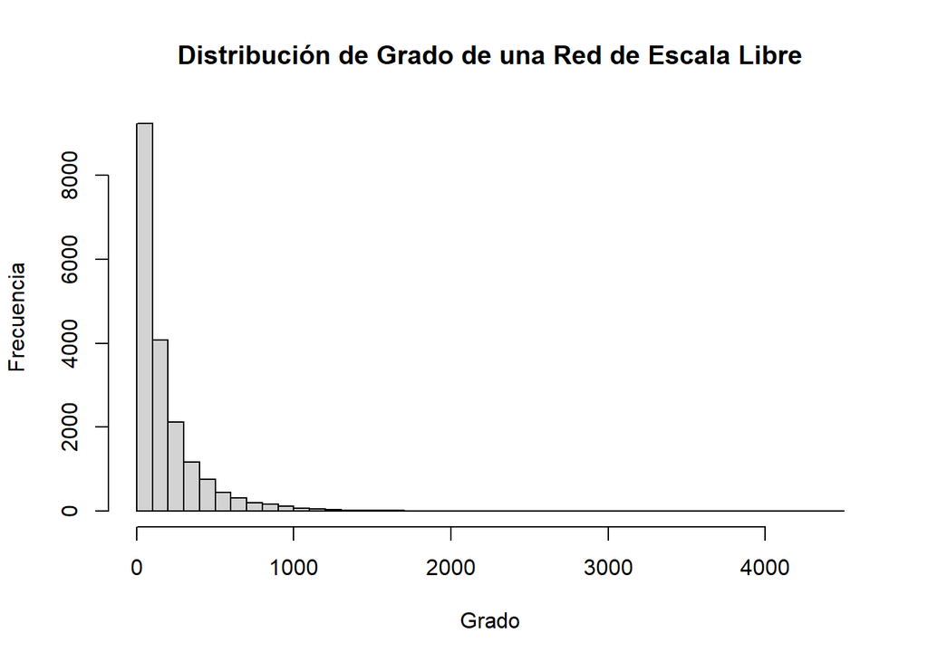

```r
# Obtener la distribución de grado
degree_distribution <- degree(g)

# Visualizar la distribución de grado
hist(degree_distribution, breaks=50, main="Distribución de Grado de una Red de Escala Libre",
     xlab="Grado", ylab="Frecuencia")
```

# 3 Clustering y output esperado

```r
# Obtener los clusters de la red
clusters <- cluster_louvain(g)

# Obtener la membresía de cada nodo
memberships <- membership(clusters)

# Asegurarte de que los nombres de los nodos están presentes
nombres_nodos <- V(g)$name

# Definir la ruta del archivo de salida en la carpeta 'results'
archivo_salida <- file.path("..", "results", "clusters_genes.txt")

# Abrir el archivo en modo de escritura
file_conn <- file(archivo_salida, "w")

# Organizar los genes por cada cluster en una lista estructurada
genes_por_cluster <- split(nombres_nodos, memberships)

# Escribir los genes por cluster en el archivo
for (cluster_id in names(genes_por_cluster)) {
  cat("Cluster", cluster_id, ":", paste(genes_por_cluster[[cluster_id]], collapse = ", "), "\n", file = file_conn)
}

# Cerrar el archivo
close(file_conn)

cat("La salida se ha guardado en:", archivo_salida)
```

```
## La salida se ha guardado en: ../results/clusters_genes.txt
```

```r
enrichment_results_clusters <- list()

for (i in seq_along(genes_por_cluster)) {
  enrichment_results_clusters[[i]] <- enrichGO(
    gene          = genes_por_cluster[[i]],   # Conjunto de genes para el cluster actual
    OrgDb         = org.Hs.eg.db,              # Base de datos de anotación de genes
    keyType       = "SYMBOL",                  # Tipo de identificador (e.g., símbolos de genes)
    ont           = "BP",                      # Ontología (BP: Proceso Biológico)
    pAdjustMethod = "BH",                      # Método de ajuste de p-valor
    pvalueCutoff  = 0.05,                      # Umbral de significancia para el p-valor
    qvalueCutoff  = 0.2                        # Umbral de significancia para el q-valor
  )
}
```

```
## No gene sets have size between 10 and 500 ...
```

```
## --> return NULL...
```

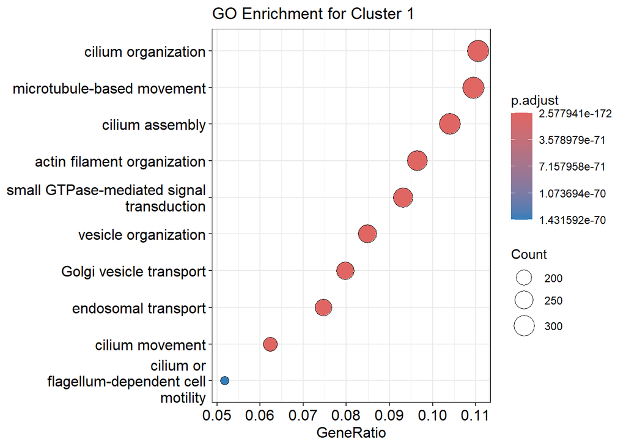

```r
# Visualización de resultados para el cluster seleccionado
cluster_a_visualizar <- params$cluster_visualizar  # Usamos el parámetro definido en el encabezado

if (cluster_a_visualizar %in% seq_along(enrichment_results_clusters)) {
  # Visualizar los resultados para el cluster seleccionado
  dotplot(enrichment_results_clusters[[cluster_a_visualizar]],
          showCategory = 10,
          title = paste("GO Enrichment for Cluster", cluster_a_visualizar))
} else {
  cat("El número del cluster ingresado no es válido.\n")
}
```

```r
# Guardar los resultados de enriquecimiento para el cluster seleccionado
cluster_a_guardar <- params$cluster_guardar  # Usamos el parámetro definido en el encabezado

if (cluster_a_guardar %in% seq_along(enrichment_results_clusters)) {
  # Definir la ruta para guardar el archivo en la carpeta 'results'
  archivo_salida <- file.path("..", "results", paste0("enrichment_cluster_", cluster_a_guardar, ".csv"))

  # Crear la carpeta 'results' si no existe
  if (!dir.exists("results")) {
    dir.create("results")
  }

  # Convertir a data frame y guardar en CSV
  write.csv2(
    as.data.frame(enrichment_results_clusters[[cluster_a_guardar]]),  # Convertir a data frame
    file = archivo_salida   # Guardar con el nombre especificado
  )
} else {
  cat("El número del cluster ingresado no es válido.\n")
}
```